# School Tweets

Andrew McCartney

January 9, 2018

Last summer, I began working with R stats more broadly and engaging in the wider data science community outside the limited social science uses that I had found for R in my statistics classes. One of these venues is the use of Sentiment Analysis to determine the general sentiment of a body of text. Additionally, I learned to use R to scrape tweets to create bodies of text for analysis.

The bulk of the analysis I’m using for this project is pulled from [David Robinson’s excellent blog post](http://varianceexplained.org/r/trump-tweets/) on the same topic.

For this analysis, I pulled in a few thousand tweets over the course of the first half of the fall 2017 semester to answer the question, ‘does the way students tweet about their college experiences change over the course of a semester?’

We’ll be using the following packages, more or less:

```r
library(tidyverse)
library(magrittr)
library(rtweet)
library(httpuv)
library(tidytext)
library(stringr)
library(wesanderson)
library(ggthemes)
library(lubridate)
library(xkcd)
```

## Data Collection

### Connect to Twitter’s API using `rtweet`:

The documentation for `rtweet` has instructions for connecting to the API and I had no trouble accessing it via modifications of their code, as such:

```r
###################################################
# Connect to Twitter's API                        #
###################################################

appname <- "pogocentchar"

## api key
key <- "jO4ts17oinXReTjBhKSLbaQQp"
## api secret key
secret <- "_____________________________________________________"

twitter_token <- create_token(
  app = appname,
  consumer_key = key,
  consumer_secret = secret, cache=TRUE)
```

### Scrape the tweets

Once you’re connected, it’s a simple matter of running code to search for your given parameters.

In this case, I sought roughly 5,000 tweets each time: these were blocked into data frames based on whether they contained a given phrase, as noted below. I began by including a lot of general education phrases but later omitted them, then only including “my professor,” “my university,” “my college,” and “my students.”

For some reason, `rtweet` tended to glitch when searching for “my university” later in the data collection process if too many tweets were included (it would save them as a list rather than as a data frame, and this couldn’t be coerced properly) so I later modified it down to 3,000 per pull.

```r
###################################################
#         Access Tweets                           #
###################################################

# tweets_teacher<- search_tweets(q = '"my teacher"', n = 5000, include_rts = FALSE)
# tweets_school <- search_tweets(q = '"my school"', n = 5000, include_rts = FALSE)
 tweets_professor <- search_tweets(q = '"my professor"', n = 5000, include_rts = FALSE)
 tweets_university <- search_tweets(q = '"my university"', n = 3000, include_rts = FALSE)
# tweets_principal <- search_tweets(q = '"my principal"', n = 5000, include_rts = FALSE)
 tweets_college <- search_tweets(q = '"my college"', n = 5000, include_rts = FALSE)
 tweets_students <- search_tweets(q = '"my students"', n = 5000, include_rts = FALSE)
```

### create data sets

Because this was going to be an ongoing project, I wanted to create and then later append the tweets to a csv rather than keeping them in an open RStudio data frame. The following code does this.

```r
###################################################
#          Create Databases  (run once)           #
###################################################
write_csv(tweets_professor, "professortweets.csv")
write_csv(tweets_university, "universitytweets.csv")
write_csv(tweets_college, "collegetweets.csv")
write_csv(tweets_students, "studentstweets.csv")

# Then later:
###################################################
#          Append Databases                       #
###################################################

write_csv(tweets_professor, "professortweets.csv", append = TRUE )
write_csv(tweets_university, "universitytweets.csv", append = TRUE )
write_csv(tweets_college, "collegetweets.csv", append = TRUE )
write_csv(tweets_students, "studentstweets.csv", append = TRUE )
```

## Data Analysis

For this part, I will only read in the tweets containing the phrase “my professor” though the same code would obviously work for all four of the corpuses we collected.

Let’s read in the data:

```r
###################################################
#  read the data back in as CSV tibble            #
###################################################

college<-read_csv("professor_tweets.csv")
college
```

```
## # A tibble: 159,900 x 35
##       screen_name      user_id      date   status_id
##             <chr>        <dbl>     <chr>       <dbl>
##  1   sydneyyyann_ 7.619940e+17 8/25/2017 9.01134e+17
##  2      D_Wayne_3 4.433687e+08 8/25/2017 9.01134e+17
##  3      DADDiNAJi 8.559610e+17 8/25/2017 9.01134e+17
##  4     teylashaye 7.418630e+17 8/25/2017 9.01134e+17
##  5   chrismarsh03 6.152302e+08 8/25/2017 9.01134e+17
##  6        DanaTDF 1.405886e+08 8/25/2017 9.01134e+17
##  7 TheMagnaCarla_ 2.477877e+09 8/25/2017 9.01134e+17
##  8     mariajozic 5.591790e+08 8/25/2017 9.01134e+17
##  9   Maggie_Bestt 4.371645e+08 8/25/2017 9.01133e+17
## 10      jerriccca 1.301500e+09 8/25/2017 9.01133e+17
## # ... with 159,890 more rows, and 31 more variables: text <chr>,
## #   retweet_count <int>, favorite_count <int>, is_quote_status <lgl>,
## #   quote_status_id <dbl>, is_retweet <lgl>, retweet_status_id <chr>,
## #   in_reply_to_status_status_id <dbl>, in_reply_to_status_user_id <dbl>,
## #   in_reply_to_status_screen_name <chr>, lang <chr>, source <chr>,
## #   media_id <dbl>, media_url <chr>, media_url_expanded <chr>, urls <chr>,
## #   urls_display <chr>, urls_expanded <chr>, mentions_screen_name <chr>,
## #   mentions_user_id <chr>, symbols <chr>, hashtags <chr>,
## #   coordinates <chr>, place_id <chr>, place_type <chr>, place_name <chr>,
## #   place_full_name <chr>, country_code <chr>, country <chr>,
## #   bounding_box_coordinates <chr>, bounding_box_type <chr>
```

```r
tweets<-college$text
# summary(tweettext)

anyDuplicated(college$status_id)
```

```
## [1] 2
```

Here we’re also creating a frame that’s just the column of tweet text, as I won’t be analyzing any of the other variables output by `rtweet` in this analysis just yet.

Additionally, I wanted to check for duplicates; i.e., if I collected tweets on two back-to-back days, did the same tweet get brought in on more than one occasion? In this case, we ended up with 159,900 tweets, so if more than a few were duplicated, this would be a problem.

## Preparing the sentiment analysis library

In earlier projects with sentiment analysis, I observed that words associated with education were almost uniformly given positive associations. I wanted to avoid coding these as such, as well as filter out words generated by inopportune apostrophes (e.g. “haven” for “haven’t”) after creating word lists, so I followed David Robinson’s code with additional modifications to pull out a general list of school words that I keep around for this purpose.

```r
# remove these school words from sentiment analysis

schoolwords<-c("school", "class", "professor", "teacher", "library", "college", "university",
               "faculty", "don", "haven", "lesson", "education", "educational", "teach",
               "principal", "excel", "educated", "tutor", "adviser", "im")
# sentiments
nrc <- sentiments %>%
  filter(lexicon == "nrc") %>%
  dplyr::select(word, sentiment)%>%
  dplyr::filter(!word %in% schoolwords)

nrc
```

```
## # A tibble: 13,867 x 2
##           word sentiment
##          <chr>     <chr>
##  1      abacus     trust
##  2     abandon      fear
##  3     abandon  negative
##  4     abandon   sadness
##  5   abandoned     anger
##  6   abandoned      fear
##  7   abandoned  negative
##  8   abandoned   sadness
##  9 abandonment     anger
## 10 abandonment      fear
## # ... with 13,857 more rows
```

Now let’s generate a general word list of the words contained in the tweets themselves, continuing to follow D Rob’s code:

```r
# David Robinson's code for cleaning text into individual words, minus stops
reg <- "([^A-Za-z\\d#@']|'(?![A-Za-z\\d#@]))"
tweet_words <- college %>%
  filter(!str_detect(text, '^"')) %>%
  mutate(text = str_replace_all(text, "https://t.co/[A-Za-z\\d]+|&amp;", "")) %>%
  unnest_tokens(word, text, token = "regex", pattern = reg) %>%
  filter(!word %in% stop_words$word,
         str_detect(word, "[a-z]")) %>%
  filter(!word %in% schoolwords)

head(tweet_words$word)
```

```
## [1] "sat"      "syllabus" "minutes"  "told"     "notes"    "damn"
```

Having done this, we can use ggplot to see what the most commonly used words are. I did this iteratively in the early stages of this project to find all of the overly-common school words that were filtered in the code above.

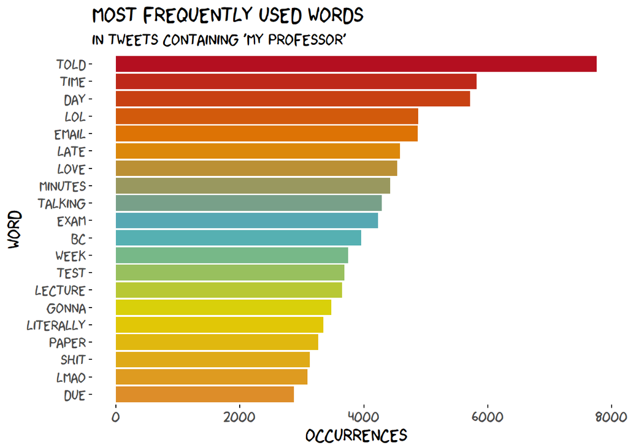

```r
wp7 <- wesanderson::wes_palette("FantasticFox",20, type="continuous")
tweet_words %>%
  count(word, sort = TRUE) %>%
  head(20) %>%
  mutate(word = reorder(word, n)) %>%
  ggplot(aes(word, n, fill=word)) +
  geom_bar(stat = "identity") +
  ylab("Occurrences") +
  coord_flip() +
  theme_xkcd()+
  scale_fill_manual(values=wp7)+
  guides(fill=FALSE)+
  labs(title="Most frequently used words",
       subtitle="in tweets containing 'my professor'")
```

A few initial observations:

The NRC sentiment library almost certainly doesn’t contain “lol” or “lmao,” so we are equally certainly biased against those, which would likely code as positive. Also “gonna” should probably be included in stop word lists going forward.

Finally, professors sure do a lot of telling, don’t they?

### Back to Sentiments

This next bit will help us see how much each sentiment is used in the tweets as a corpus:

```r
sentimental<-tweet_words %>%
  inner_join(nrc, by = "word") %>%
  count(sentiment, sort=TRUE)
sentimental
```

```
## # A tibble: 10 x 2
##       sentiment     n
##           <chr> <int>
##  1     positive 75099
##  2     negative 74322
##  3 anticipation 43362
##  4        trust 38217
##  5      sadness 36243
##  6          joy 34205
##  7         fear 31149
##  8        anger 30505
##  9      disgust 24603
## 10     surprise 18993
```

And then we can visualize this as such:

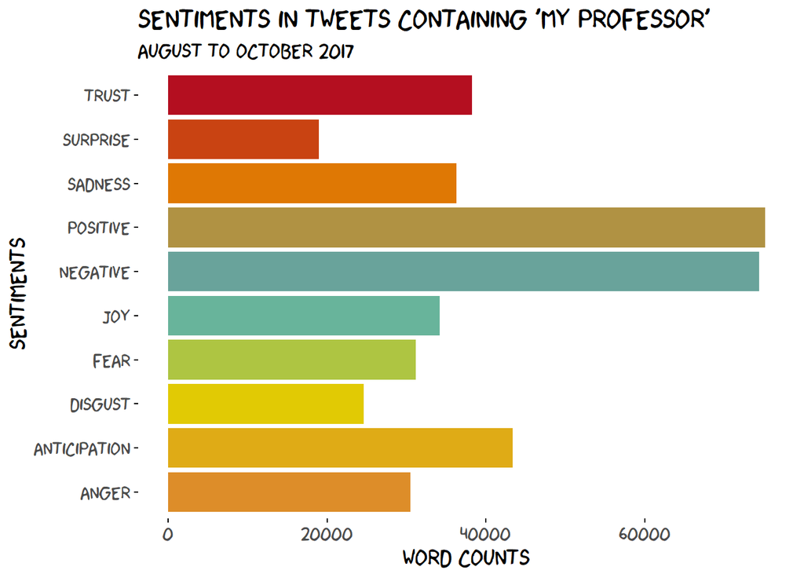

```r
wp8 <- wesanderson::wes_palette("FantasticFox",10, type="continuous")
collegesent<-ggplot(sentimental, aes(sentiment,  n, fill=sentiment))+geom_col()+coord_flip()
collegesent +
  scale_fill_manual(values = wp8) +
  theme_xkcd()+
  labs( x="Sentiments", subtitle = "August to October 2017",
        y = "Word Counts",
        title="Sentiments in tweets containing 'my professor'")+
  guides(fill=FALSE)
```

Okay, so that tells us that “positive” and “negative” are the real majority of codes. It might be worth it to explore these data sets by subsetting them out for their own separate analysis.

### Visualizing over time

However, what we really want to know is: do these change over the course of a semester?

Here we encounter our first real problem: the “created_at” column generated by `rtweet` gives a date time as, e.g., `2017-08-25T17:28:39Z` and we need this to be in a better format, such as `8/25/2017` for our next lines of code.

In my initial work, I manually changed these in excel using a few well-placed find-and-replace calls, but here is some code that will make these changes more efficiently in R:

```r
college$date<-format(as.POSIXct(college$created_at, format='%Y-%m-%d- %H:%M:%S'), format='%m/%d/%Y')
```

The reason we care about dates is twofold: first we wish to map over time, but we also wish to normalize over time, which is to say that we are going to divide each count of sentiments by the total number of tweets collected on that given day, to account for the fact that I did not collect every tweet on every day, and to account for any changes in tweet volume over, say, days of the week.

The following lines of code will accomplish this for us.

```r
get_norms <- college %>%
  count(date) %>%
  rename(tweets_on_date = n)

get_norms$date<-mdy(get_norms$date)
get_norms
```

```
## # A tibble: 56 x 2
##          date tweets_on_date
##        <date>          <int>
##  1 2017-10-10           4047
##  2 2017-10-11           1749
##  3 2017-10-12           5513
##  4 2017-10-13           2269
##  5 2017-10-14            921
##  6 2017-10-15           1150
##  7 2017-10-16           3842
##  8 2017-10-17            574
##  9 2017-10-18           5085
## 10 2017-10-19           4601
## 11 2017-10-02            741
## 12 2017-10-03           5618
```

[output cut: 44 more lines]

Next to re-create a sentiment correspondence, but this time accounting for each group of sentiments by date.

```r
sentimental_journey <- tweet_words %>%
  inner_join(nrc, by = "word") %>%
  count(sentiment, date = date) %>%
  rename(sentiment_count = n)
sentimental_journey$date<-mdy(sentimental_journey$date)
sentimental_journey
```

```
## # A tibble: 560 x 3
##    sentiment       date sentiment_count
##        <chr>     <date>           <int>
##  1     anger 2017-10-10             824
##  2     anger 2017-10-11             381
##  3     anger 2017-10-12            1091
##  4     anger 2017-10-13             445
##  5     anger 2017-10-14             168
##  6     anger 2017-10-15             235
##  7     anger 2017-10-16             782
##  8     anger 2017-10-17             115
##  9     anger 2017-10-18            1031
## 10     anger 2017-10-19             957
## # ... with 550 more rows
```

And now apply the two together by dividing the sentiment count per day by the total tweets per day to get a proportion:

```r
sj<-sentimental_journey %>%
  inner_join(get_norms, by = "date")
sj$norms<-(sj$sentiment_count)/(sj$tweets_on_date)
sj
```

```
## # A tibble: 560 x 5
##    sentiment       date sentiment_count tweets_on_date     norms
##        <chr>     <date>           <int>          <int>     <dbl>
##  1     anger 2017-10-10             824           4047 0.2036076
##  2     anger 2017-10-11             381           1749 0.2178388
##  3     anger 2017-10-12            1091           5513 0.1978959
##  4     anger 2017-10-13             445           2269 0.1961216
##  5     anger 2017-10-14             168            921 0.1824104
##  6     anger 2017-10-15             235           1150 0.2043478
##  7     anger 2017-10-16             782           3842 0.2035398
##  8     anger 2017-10-17             115            574 0.2003484
##  9     anger 2017-10-18            1031           5085 0.2027532
## 10     anger 2017-10-19             957           4601 0.2079983
## # ... with 550 more rows
```

Finally, we will graph these to see what changes take place over time:

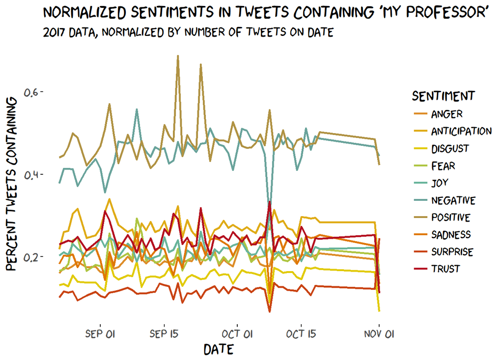

```r
collegesent_time<-ggplot(sj, aes(x = date, y = sj$norms,  group=factor(sentiment), color = sentiment)) +
  geom_line(size = 1) +
  scale_color_manual(values = wp8) +
  scale_x_date(date_labels = "%b %d") +
  labs(title="normalized sentiments in tweets containing 'my professor'",
       subtitle="2017 Data, normalized by number of tweets on date",
       y = "percent tweets containing",
       x = "date") +
  theme_xkcd()
collegesent_time
```

Frankly, all I see are the places where I failed to collect tweets every day (a long gap at the end of October, where I was in my own midterm hell).

In fact, going through the “tweets_on_date” column shows that the biggest changes in the graph are on days in which I collected tweets shortly after midnight and got all the 12:00-1:00 am tweets, plus a few thousand from the day before, generating skewed days where there are only a few hundred tweets collected. Why is this a problem if I normalized by total daily tweets? Because the relative rarity of some of these words and their associations means that they are only in, e.g., 10% of tweets on that day, and that means only 20 or so times on some days. The cumulative effect still skews.

In short, all the parts of the data that are trustworthy to me show that there is no broad trend in changes of how students tweet about their professors.